# ExamPrepFinalized

```python
import numpy as np
```

- Exam 2021
  - Problem 1 - Correlation Functions
    - 1.1 - biased cross-correlation $\hat{r}_xy$
    - 1.2 - Analytic expression derivation of auto-corr function $r_x(k)$
    - 1.2 - New info. Is it second order ergodic?
  - Problem 2 - Parameter Estimation
    - 2.1 - Determine least squares estimate of $b$ and $\theta$
    - 2.2 - Biased estimator $\alpha$ value MSE
    - 2.3 - Value of $\lambda$ if $\theta^{(i)}=3$ using IST
    - 2.4 - Bayesian viewpoint Ridge Regression. Value of measurement noise given $\lambda=2$
    - 2.5 - Bayesian approach: complete log-likelihood as a function of $\sigma_\eta^2$ and $\sigma_\theta^2$
  - Problem 3 - Linear adaptive filtering (FIR) $l=3$
    - 3.1 - Given correlation function values $r_u$, $r_{du}$ and $r_d$ find filter coefficient values $w$ and minimum mean squared error (MMSE) achieved by filter
    - 3.2 - Determine steady-state excess MSE $J_{exc}$ when using LMS for $\mu=0.5$
  - Problem 4 - Dictionary learning (ICA)
    - 4.1 - Given $X$ and $Z$ determine mixing matrix $A$
    - 4.2 - Which of the following statements is **false** w.r.t. ICA?
  - Problem 5 - State-space models and time-frequency analysis
    - 5.1 - Determine number of samples per window and number of windows processed by STFT (given a 10 minute signal, a sampling rate of 5 Hz, window size of 30 seconds and window overlap of 50%)
    - 5.2 - Hidden Markov Model: Estimate as many parameters given information provided
    - 5.3 - Calculate probability of running in 60-90s interval given only high frequency content was observed in the first 90 seconds
  - Problem 6 - Kernels (ch. 11)
    - 6.1 - Apply Gaussian Kernel function and argue if it can be used to separate the classes
    - 6.2 - Kernel Ridge Regression and 3 data points. Compute $\theta$ and specify formulas
    - 6.3 - Kernel RR 3 observations. Find $\theta_3$ given $\theta_1,~\theta_2,\kappa(x,x_n),~\text{and}~\hat{y}(x)=3$
- Exam 2022
  - Problem 1 - Parameter estimation
    - 1.1 - Linear regression: Determine parameters $\hat{\theta}$ which minimizes error.
    - 1.2 - Ridge Regression: Derive closed form expression for $\lambda$ and determine which $\lambda$ was used given estimated parameters $\theta_R=[-0.41~~1]^T$
    - 1.3 - Assume $X^TX=2I$ and LS estimate $\hat{\theta}_{LS}=[-.75~~1.3]^T$. Derive expression for $\hat{\theta}_R$ and determine its value.
    - 1.4 - Apply $l_1$ regulartization using $\lambda=0.5$. Using IST for one iteration, determine the lowest value of $\mu$ that results in **exactly one** component of $\theta^{(i)}$ being zero.
    - 1.5 - Ridge regression ($\lambda=0.5$). Assume $\sigma^2=0.3$ for the noise. How does this relate to the prior distribution of $\theta$? Determine the prior variance.
  - Problem 2 - Linear Filtering (FIR)
    - 2.1 - Given input sequence and filter weight coeff. $w$, determine the output of the filter at $n=3$.
    - 2.2 - Derive expressions for correlation functions $r_u$, $r_{du}$ in terms of $r_s$, $r_x$ and $r_\eta$.
    - 2.3 - Given correlation function values, determine coefficient values $w$ using $l=3$ and minimum mean square error MMSE.
    - 2.4 - Consider LMS and $\mu=0.1$ and weights given $n=2$ as described in problem before, same with input. Assume $d_3=3$. Determine the new value of filter coefficient at $n=3$ using LMS.
    - 2.5 - Consider RLS with $l=2$. Determine steady-state excess MSE for RLS using $\beta=0.95$. Determine $\beta$ that results in lowest excess MSE.
  - Problem 3 - Dictionary learning (ICA)
    - 3.1 - Four microphones, four sources, attentuated by distance $d$ and various filters. Write up mixing matrix $A$.
    - 3.2 - What is **false** about ICA using Mutual Information?
  - Problem 4 - Hidden Markov Models (HMM)
    - 4.1 - 2-state HMM with sequence of $N=37$ elements and $P_{ij}$. What are the most likely transition probabilities? Argue.
    - 4.2 - Given Table, compute probability of being in state $k=1$ at time $n=2$ given observations $y_{1:5}$.
  - Problem 5 - Kalman Filtering (AR(3) w. white noise)
    - 5.1 - Given noisy version of signal, setup components ($x_n$, $F$, $\eta_n$, $H$, and $v_n$) such that Kalman filter algorithm can be used.
  - Problem 6 - Kernel methods (Laplacaion and Polynomial kernel $r=1$)
    - 6.1 - Given figure, which kernel is most appropriate? Explain and relate to representer theorem, ie. what are possible values of $\theta_n$.
    - 6.2 - Kernel ridge regression w. Laplacian using $a=0.5$ on data fitted using $C=0.01$. Compute regression value for $\hat{y}$ at $t=1$, disregard any kernel value below 0.1.
    - 6.3 - Support Vector Regression with $\epsilon$-insensitive loss using $C=1$. Support vectors are crosses. Identify $\epsilon$ used for data-fit.
- Exam 2023
  - Problem 1 - Parameter Estimation
    - 1.1 - Polynomial regression, determine parameters $\hat{\theta}$ that minimize the error.
    - 1.2 - Linear model with non-white Gaussian noise and variance of noise $\sigma_\eta=1$, covariance two successive samples is $0.2$, determine parameters.
    - 1.3 - Compute $\hat{\theta}_{agg}$ across $N=10$ different realizations using unbiased estimator $\hat{\theta}_i$, where each individual estimator's variance is $\sigma^2=1$.
  - Problem 2 - Sparse Learning ($l1$/linear regression)
    - 2.1 - IST, determine smallest value of $\lambda$ that results in **both** components in $\theta^{(i)}=0$ using $\mu=0.1$
    - 2.2 - Assume $\lambda=1$ and reliable estimate of noise $\sigma^2=1$. How does linear/LASSO regression relate to prior distribution of $\theta$? Define the parameters. (Laplacian)
  - Problem 3 - Linear Filtering (FIR)
    - 3.1 - Determine filter weight $w_2$ used to find $\hat{y_4}$ given that $n=4$ and $\hat{y}_4=3.1$ and $w=[0.50~~0.30~~w_2]^T$
    - 3.2 - (WSS) Derive analytical expression for cross-correlation function $r_{yu}(k)$.
    - 3.3 - Given $r_u(k)$ and $r_{du}(k)$ for $d_n$ and $u_n$ determine filter coefficients $w$ using $l=3$. Also, find highest tolerable value for $r_d(0)$ if the MMSE is at most 0.1.
    - 3.4 - Determine maximum value of step-size $\mu$ using LMS and given $\Sigma_u$. Ensure that **filter converges** AND weight estimator has **bounded variance**.
    - 3.5 - Using NLMS determine range of $\mu$ that ensures the excess MSE is at most 0.1, while NLMS has to guaranteed to remain **stable** as well.
  - Problem 4 - Dictionary Learning (ICA)
    - 4.1 - ICA: Given 2 sources $s_1$ and $s_2$, identify umixing matrix W such that the average mutual information is zero. Show formally!
    - 4.2 - Write short proof that ICA has scaling ambiguity.
  - Problem 5 - Hidden Markov Models (HMM)
    - 5.1 - Suppose 3-state HMM with given $P_k$ and $P_{ij}$ and sub-sequences $A,B,C,D$. Specify composition that creates most likely state sequence, and justify choices.
    - 5.2 - HMM allows $i=3$ possible observable actions $a_i$. Compute initial state probability vector $P_k$.
  - Problem 6 - Kalman filtering
    - 6.1 - Calculate updated state estimate $\hat{x}_1$ and error covariance $P_1$ after receiving first measurement given initial state and probability (Multiple choice).
  - Problem 7 - Kernel methods
    - 7.1 - Gaussian kernel given 8 data points (figure). Write kernel matrix $\mathcal{K}$ for the data using $\sigma=2$.
    - 7.2 - Assume two test points belonging to each of two classes are given. Use representer theorem to determine how these can be classified correctly.
    - 7.3 **[NOT DONE]** - Support vector regression on 5 data points using $C=1$ and $\epsilon=0.1$ with $\hat{\theta}_0$ = 0 as bias. Compute either exact or tight bound for $\hat{y}(x^{test})$

```python
### Helper functions
def J_exc_LMS(Sigma_x, Sigma_omega, sigma_eta_squared, mu, precision=3):
    """Calculate the excess MSE for the LMS algorithm. (Table 6.1)"""
    LHS = 1/2 * mu * sigma_eta_squared * np.trace(Sigma_x)
    RHS = 1/2 * mu**(-1) * np.trace(Sigma_omega)
    return round(LHS + RHS, precision)

def J_exc_RLS(Sigma_x, Sigma_omega, sigma_eta_squared, filter_length, beta, precision=3):
    """Calculate the excess MSE for the RLS algorithm. (Table 6.1)"""
    LHS = 1/2 * (1-beta) * sigma_eta_squared * filter_length
    RHS = 1/2 * (1-beta)**(-1) * np.trace(Sigma_omega @ Sigma_x)
    return round(LHS + RHS, precision)

def J_exc_NLMS(Sigma_x, Sigma_omega, sigma_eta_squared, mu, norm_input, precision=3):
    """
    Calculate the excess MSE for the NLMS algorithm.
    expectation_q is the expected value of q=1 over the squared norm of the input signal.
    If used, please refer to Table 6.1 in the book.
    """
    LHS = 1/2 * mu * sigma_eta_squared * np.trace(Sigma_x) * ( 1 / norm_input )
    RHS = 1/2 * mu**(-1) * np.trace(Sigma_omega) * np.trace(Sigma_x)
    return LHS + RHS

def biased_crosscor(x, y, k):
    """
    Calculate the biased cross-correlation between two signals x and y for lag k,
    denoted as ^r_xy(k).It is called auto-correlation if x = y.
    !! See exercise 3.1.3. !!
    """
    N = len(x)
    if len(y) != N:
        raise ValueError("Signals x and y must have the same length.")
    # Compute the biased cross-correlation
    correlation = 0
    for n in range(k, N):
        correlation += x[n] * y[n - k]
        print(f"n={n}: x(n)= {x[n]}, y(n-k)= {y[n - k]}")

    return correlation / N

def gaussian_kernel(x, y, sigma):
    return np.exp( - ((x - y)**2) / (2 * sigma**2) )

def homogeneous_polynomial_kernel(x, y, r):
    return (x.T @ y)**r

def laplacian_kernel(x, y, a):
    return np.exp((a) * np.linalg.norm(np.abs(x-y)))
```

# Exam 2021

## 21 Problem 1

### 21 1.1

Consider the following sequence starting at $n=0$:

$$y_n=\{5,3,6,2\}$$

Calculate the biased auto-correlation value for $r_y(0)$ and $r_y(3)$.

#### Answer

The biased cross-correlation is defined in exercise 3.1.3 as:

$$\hat{r}_{xy} = \frac{1}{N}\sum^{N-1}_{n=k}x(n)y(n-m),~~~\text{for } k=0,1,\dots,N-1$$

Inserting we have:

```python
y_n = [5, 3, 6, 2]
k = 0
print(f"r_xy({k}) = {biased_crosscor(y_n, y_n, k)}")

k = 3
print(f"r_xy({k}) = {biased_crosscor(y_n, y_n, k)}")
```

```
n=0: x(n)= 5, y(n-k)= 5
n=1: x(n)= 3, y(n-k)= 3
n=2: x(n)= 6, y(n-k)= 6
n=3: x(n)= 2, y(n-k)= 2
r_xy(0) = 18.5
n=3: x(n)= 2, y(n-k)= 5
r_xy(3) = 2.5
```

### 21 1.2

Consider the signal $x_n = \alpha y_{n-d_1}+\beta z_{n-d_2}$. The signals $y_n$ and $z_n$ are wide-sense stationary processes (WSS). Assume $r_y(k)$, $r_z(k)$ and $r_yz(k)$ are known.

Determine an analytic expression of the auto-correlation function $r_x(k)$

#### Answer

Exercise 3.1.1 has the same structure. Recall, WSS processes can be freely time-shifted! We have to expand the following:

$$\begin{align*} r_x(k)&=\mathbb{E}[x_n x_{n-k}] \\ &=\mathbb{E}[(\alpha y_{n-d_1}+\beta z_{n-d_2})(\alpha y_{n-d_1-k}+\beta z_{n-d_2-k})] \end{align*} $$

Now one can either $d=d_2-d_1$ to get the same form as exercise 3.1.1, or can take the long way:

$$\begin{align*} r_x(k)&=\mathbb{E}[x_n x_{n-k}] \\ &=\mathbb{E}[(\alpha y_{n-d_1}+\beta z_{n-d_2})(\alpha y_{n-d_1-k}+\beta z_{n-d_2-k})] \\ &=\mathbb{E}[\alpha^2 y_{n-d_1}y_{n-d_1-k}+\beta^2 z_{n-d_2}z_{n-d_2-k}+\alpha\beta y_{n-d_1}z_{n-d_2-k}+\alpha\beta z_{n-d_2}y_{n-d_1-k}] \\ &= \mathbb{E}[\alpha^2 y_{n}y_{n-k}+\beta^2 z_{n}z_{n-k}+\alpha\beta y_{n-d_1+d_1}z_{n-d_2-k+d_1}+\alpha\beta z_{n-d_2+d_2}y_{n-d_1-k+d_2}] \\ &= \mathbb{E}[\alpha^2 y_{n}y_{n-k}+\beta^2 z_{n}z_{n-k}+\alpha\beta y_{n}z_{n-(d_2+k-d_1)}+\alpha\beta z_{n}y_{n-(d_1+k-d_2)}] \\ &= \alpha^2 r_y(k) + \beta^2 r_z(k)+\alpha\beta r_{yz}(d_2+k-d_1) +\alpha\beta r_{zy}(d_1+k-d_2) \\ &=\alpha^2 r_y(k) + \beta^2 r_z(k)+\alpha\beta r_{yz}(d_2+k-d_1) +\alpha\beta r_{yz}(d_2-k-d_1) \tag{\text{Sol.}} \end{align*} $$ Recall that the following property holds for cross-correlation (property 2.120) in ML book:

$$ r_{uv}(k)=r^*_{vu}(-k) $$

Since both $y_n$ and $y_{n-k}$ (same for $z$) are shifted by $d_1$ and $d_2$, respectively, we can simply shift them by the same amount when it only concerns the two expressions. Note, for the rest, we want a form of $\mathbb{E}[\cdot_n \cdot_{n-(k)}]$, so we can shift the entire sequence by adding $+d_1$ and $+d_2$ onto the $y$ and $z$ component, respectively. See above. In the cross-over, we add either $+d_1$ or $+d_2$ to the entire sequence dependent on which one yields the form above.

The parenthesis is made and we **CHANGE THE SIGN**. Then we use linearity of expectations and recognize each element as their respective correlation functions.

### 21 1.3

Consider same $x_n$. Assume $y_n \sim AR(1)$, ie. $y_n=a_1y_{n-1}+\eta_n$. $z_n$ is a random variable taking *one* value and is drawn from $\text{Uniform}(0,1)$. Assume $\mathbb{E}[y_n]=0$

Determine if it is a second order ergodic process.

#### Answer

- The signal is WSS (mean and auto-correlation depend only on time differences)
  - ie. must be stationary
- Time average for mean and auto-correlation converge to respective ensemble averages.
- Has finite variance.

Since $z_n$ is a single realization, its mean and auto-correlation will become non-stationary as the specific time realizations will have different mean values. In other words $z_n$ is not random across realizations, but fixed ($z_n=z_{n+1}$). Hence, $x_n$ is not WSS, which is a prerequisite for second order ergodic processes.

## 21 Problem 2

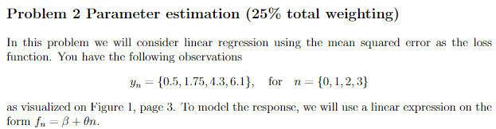

### 21 2.1

Determine the least squares (LS) estimate of the coefficients $b$ and $\theta$. Write up the matrices and vectors used to calculate the estimate.

#### Answer

Recall: $$\hat{\mathbf{\theta}}_{LS}=(\mathbf{X}^T\mathbf{X})^{-1}\mathbf{X}^T\mathbf{y}$$ Remember the design matrix $X$ contains to the bias and the number of predictors. The model response was $f_n=\beta + \theta n$, hence the predictors are simply $n$

```python
y_n = np.array([0.5, 1.75, 4.3, 6.1])
n = np.arange(len(y_n))
bias = np.ones(len(y_n))
X = np.array([bias, n]).T
print(f"X = \n{X}")
print(f"y_n = {y_n}")
print(f"LS estimate:\n[b, theta] = {np.linalg.inv(X.T @ X) @ X.T @ y_n}")
```

```
X =
[[1. 0.]
 [1. 1.]
 [1. 2.]
 [1. 3.]]
y_n = [0.5  1.75 4.3  6.1 ]
LS estimate:
[b, theta] = [0.26  1.935]
```

### 21 2.2

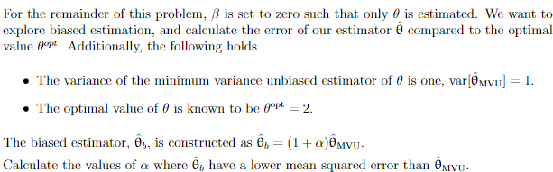

#### Answer

Recall that we may find the optimal parameters that are biased such as $\hat{\theta}_b=(1+\alpha)\hat{\theta}_u$ then value of $\alpha$ where our biased estimater has a lower MSE than its unbiased counterpart is given by (*ML 3.5.1, (3.21) and (3.26)*): $$-\frac{2\text{MSE}(\hat{\theta}_u)}{\text{MSE}(\hat{\theta}_u)+\theta_o^2}<\alpha<0$$ where we have $\text{VAR}[\hat{\theta}_{MVU}]$ and $\theta_o$, so:

$$-\frac{2\text{MSE}(\hat{\theta}_u)}{\text{MSE}(\hat{\theta}_u)+\theta_o^2} = -\frac{2 \cdot 1}{1+2^2} = -\frac{2}{5}<\alpha<0$$

### 21 2.3

keywords: (IST, iterative, shrinkage, thresholding, $\lambda$, $l_1$ regularization, step-size)

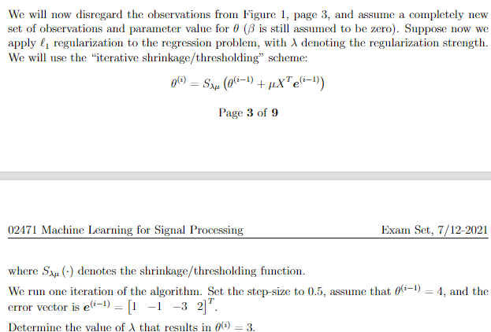

#### Answer

**NOTE** $X^TX=I$ IS NOT SPECIFIED SO WE USE THE BELOW, OTHERWISE WE WOULD USE FORMULA FROM ex 6.2 OR chapter 9.3

$\theta^{(i)}=S_{\lambda\mu}(\tilde{\theta})$ is given by (10.7) in the book, where $S_{\lambda\mu}(\tilde{\theta})$ is given by slides as :

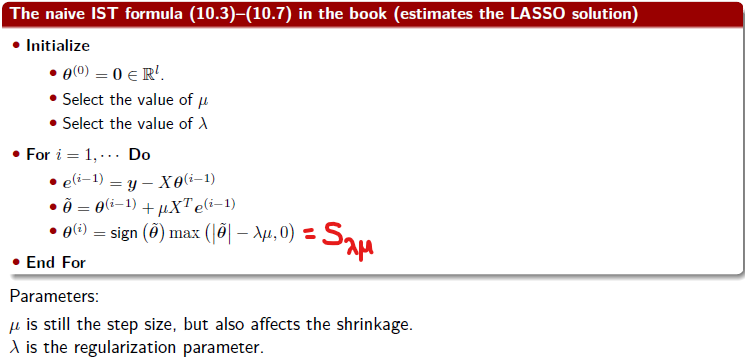

Hence:

$$ \begin{align*} \theta^{(i)}&=S_{\lambda\mu}(\tilde{\theta}) = S_{\lambda\mu}(\theta^{(i-1)}+\mu X^T e^{(i-1)})\\ &=S_{\lambda\mu}(4 + 0.5 \cdot \begin{bmatrix}0 & 1 & 2 & 3\end{bmatrix}\begin{bmatrix}1 & -1 & -3 & 2\end{bmatrix}^T) \\ &= S_{\lambda\mu}(3.5) \\ &=\text{sign}(\theta)\text{max}(|\theta|-\lambda\mu,0)=\text{sign}(3.5)\text{max}(|3.5|-\lambda 0.5,0) \end{align*} $$

```python
step = 0.5
theta_prev = 4
error_prev = np.array([1, -1, -3, 2]).T
X = np.array([0, 1, 2, 3]).T
S = (theta_prev + step * X.T @ error_prev)
for reg_choice in range(0,3):
    theta_i = np.sign(S) * np.maximum(np.abs(S) - reg_choice * step, 0)
    print(f"lambda={reg_choice}: {theta_i}")
```

```
lambda=0: 3.5
lambda=1: 3.0
lambda=2: 2.5
```

### 21 2.4

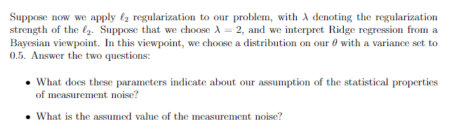

#### Answer

You are supposed to read off that this pertains to Gaussian white noise (exercise 9.1.2). ML 12.2.2 p598 under (12.12) a small note says $\lambda=\frac{\sigma_\eta^2}{\sigma_\theta^2}$

- Measurement noise is Gaussian white noise which is statistically independent from sample to sample, ie $\eta\sim\mathcal{N}(\mu_\eta,\Sigma_\eta)$ with uncorrelated residuals
- $\lambda=2=\frac{\sigma_\eta^2}{\sigma_\theta^2} \Leftrightarrow \sigma_\eta^2=2 \cdot \sigma_\theta^2=2 \cdot 0.5 = 1$

### 21 2.5

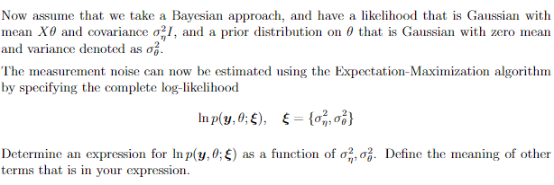

#### Answer

Look at ML p614, where it is noted we instead would use precision variables. Hence $\alpha=\frac{1}{\sigma_\theta^2}$ and $\beta=\frac{1}{\sigma_\eta^2}$. Inserting we then have:

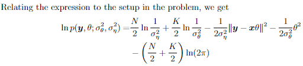

Recall $K$ is the number of weights and $N$ is the number of points, ie. $K=1$ and $N=4$, so:

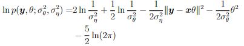

## 21 Problem 3

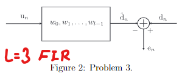

### 21 3.1

You get the following correlation functions:

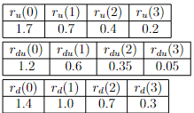

Determine the filter coefficient values $w$ and the minimum mean squared error (MMSE) as achieved by the filter.

#### Answer

This is the exact system from Figure 4.5 in the ML book p. 135, where we have a new form of the normal equation (4.5) given by p. 136 as: $$\Sigma_u w = R_u w = p \Leftrightarrow w = R_u^{-1} p$$

Since we have been given $R_u$ and $p$, we can readily find that below.

The MMSE is given by eq. (4.9) in the book p. 123 as:

$$MMSE = J(\theta_*) = \sigma_y^2-p^T\theta_*$$

However, here we remark that $w$ is indeed the parameter, so $\theta_*=w_*$ and $\sigma_y^2=\sigma_d^2=r_d(0)$

```python
np.set_printoptions(3)
ru0=1.7; ru1=0.7; ru2=0.4; ru3=0.2
rdu0=1.2; rdu1=0.6; rdu2=0.35
R_u = np.array([[ru0, ru1, ru2],
                [ru1, ru0, ru1],
                [ru2, ru1, ru0]])
p = np.array([[rdu0],
              [rdu1],
              [rdu2]])
print(f"R_u = \n{R_u}")
print(f"p = \n{p}")
w = np.linalg.inv(R_u) @ p
print(f"w = \n{w}")

rd0 = 1.4 # This is the same as \sigma^2_d
MMSE = rd0 - w.T @ p
print(f"MMSE = {MMSE}")
```

```
R_u =
[[1.7 0.7 0.4]
 [0.7 1.7 0.7]
 [0.4 0.7 1.7]]
p =
[[1.2 ]
 [0.6 ]
 [0.35]]
w =
[[0.673]
 [0.068]
 [0.02 ]]
MMSE = [[0.544]]
```

### 21 3.2

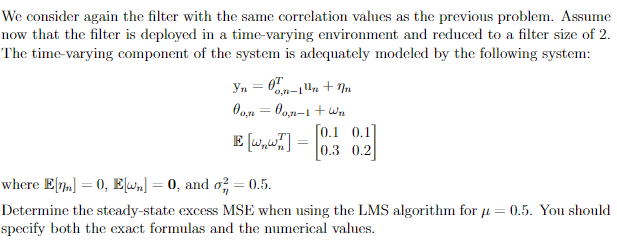

#### Answer

Recognize $l=2$ now. Hence $\Sigma_u$ changes! The steady-state excess can be found in the ML book in table 6.1, p276:

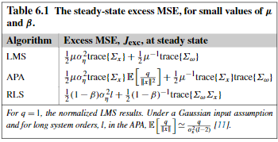

Hence we get, using $y_n$ which takes input $u_n$:

$$\begin{align*} J_{exc} &\simeq \frac{1}{2}\mu\sigma_\eta^2\text{trace}\{\Sigma_x\}+\frac{1}{2}\mu^{-1}\text{trace}\{\Sigma_\omega\} \\ &= \frac{1}{2} \cdot 0.5 \cdot 0.5 \cdot (r_u(0) + r_u(0)) + \frac{1}{2}\cdot\bigg(\frac{1}{2}\bigg)^{-1}\cdot(0.1 + 0.2)\\ &= 0.725 \end{align*} $$

```python
J_exc = 1/2 * 1/2 * 1/2 * (1.7 + 1.7) + 1/2 * (1/2)**(-1) * (0.1 + 0.2)
l = 2; mu = 1/2; sigma_eta_squared = 0.5
Sigma_omega = np.array([[0.1, 0.1],
                        [0.3, 0.2]])
J_exc_LMS = J_exc_LMS(R_u[:l, :l], Sigma_omega, sigma_eta_squared, mu, precision=3)
print(J_exc)
print(J_exc_LMS)
```

```
0.7250000000000001
0.725
```

## 21 Problem 4

Independent Component Analysis (ICA)

### 21 4.1

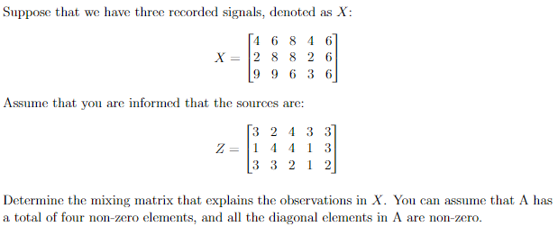

#### Answer

Recall in ICA that the mixing matrix $A$ is part of the equation given in slide 29 week 8 (although given by (19.44) as $Z=s$):

$$X = AZ \Leftrightarrow XZ^T = AZZ^T \Leftrightarrow XZ^T(ZZ^T)^{-1}=A$$

```python
np.set_printoptions(suppress=True)
X = np.array([[4, 6, 8, 4, 6],
              [2, 8, 8, 2, 6],
              [9, 9, 6, 3,6]])
Z = np.array([[3, 2, 4, 3, 3],
              [1, 4, 4, 1, 3],
              [3, 3, 2, 1, 2]])
A = X@Z.T @ np.linalg.inv(Z@Z.T)
print(f"A = \n{A}")
```

```
A =
[[ 1.  1.  0.]
 [-0.  2.  0.]
 [-0.  0.  3.]]
```

### 21 4.2

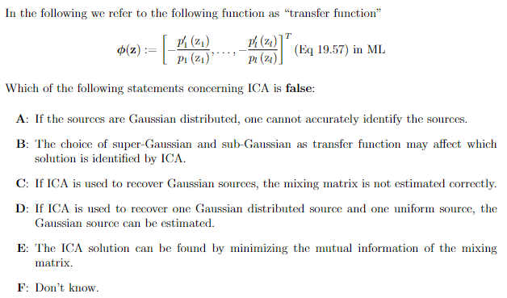

## 21 Problem 5

State-space models and time-frequency analysis.

### 21 5.1

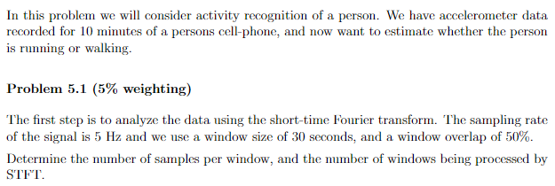

#### Answer

See slide 33 week 7, which states the STFT is given by:

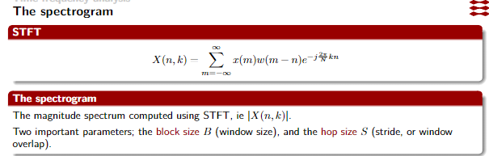

In other words, the signal $x$ is $10$ minutes so $10\times60=600s$ and sampled at a rate of $F_s=5Hz$ so there is a total of $600s \times 5Hz = 3000$ samples.

Furthermore, we identify that the window size is $B=30s$ and the hop size $S=50\%$.

Recall, the number of samples per window is:

$$ \text{Samples per window}=B\times F_s = 30 \times 5 = 150 \text{samples} \\ \text{Hop size in samples}=\text{Samples per window}\times\frac{1}{2}=\frac{150}{2}=75 \text{samples} \\ \text{No. windows}=\frac{\text{Total samples} - \text{Samples per window}}{\text{Hop Size}} + 1 \\ = \frac{3000 - 150}{75}+1 = 38 + 1 = 39. $$

Alternatively the solution found: $$\text{No. windows} = \frac{\text{Total signal length}}{\text{Window size} \times \text{Window overlap}} - 1$$

```python
signal_seconds = 10 * 60
window_size = 30
hop_size = 1/2
nr_windows = (signal_seconds / (window_size * hop_size)) - 1
print(f"Number of windows: {nr_windows}")
```

```
Number of windows: 39.0
```

### 21 5.2

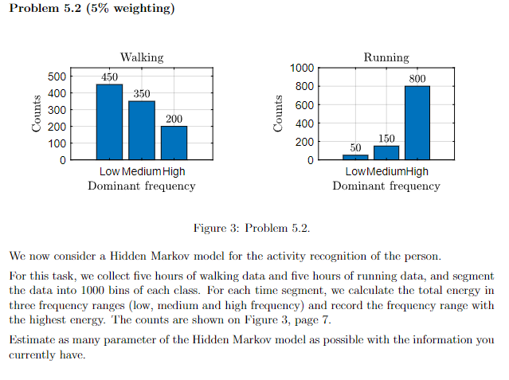

#### Answer

HMM is fully described by the parameters:

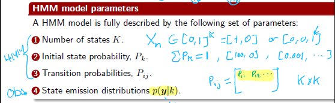

$$ P_k(Y|k=\text{Walking}) = \begin{bmatrix} \frac{450}{1000} & \frac{350}{1000} & \frac{200}{1000} \end{bmatrix} \\ P_k(Y|k=\text{Running}) = \begin{bmatrix} \frac{50}{1000} & \frac{150}{1000} & \frac{800}{1000} \end{bmatrix} $$

We cannot estimate any other parameters with the given information provided.

### 21 5.3

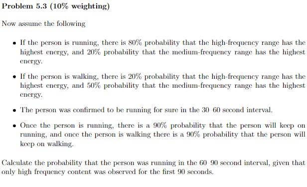

#### Answer

Here the trick is to use Markov property, ie. we only need the previous state to determine the present. In other words, we discard the observations for the first 60 seconds. The initial probability $P_{running} = 1$ then.

We seek:

$$ P(x_n=\text{running}|y_n=\text{high frequency}) $$

We can find the probability described in ML ch. 16.5.1, p.850/851, where we do not have future data $\beta$, hence with message passing function $\alpha()$: $$ P(x_n|y_{[1:n]}) = \frac{\alpha(x_n)}{p(y_{[1:n]})} = \frac{\alpha(x_1=\text{running})}{p(y_1)} \\ = \frac{\alpha(x_1=\text{running})}{\alpha(x_1 = \text{walking} ) + \alpha(x_1=\text{running})} $$

Given (16.41) we have the $\alpha(x_n) = p(y_1,y_2,...,y_n,x_n)$ so:

$$ \alpha(x_1) = p(y_1,x_1) = p(y_1|x_1)p(x_1) \\ \Rightarrow \\ (1)~~~~\alpha(x_1=r)=p(y_1=hf|x_1=r)p(x_1=r) \\ (2)~\alpha(x_1=w)=p(y_1=hf|x_1=w)p(x_1=w) $$ where $r$ is running, $w$ is walking and $hf$ is high frequency.

We know the person is running, so the transition probabilities $P_{rw}$ can be found: $$ \alpha(x_1=r)=p(y_1=hf|x_1=r)p(x_1=r) = 0.8 \times 0.9 = 0.72\\ \alpha(x_1=w)=p(y_1=hf|x_1=w)p(x_1=w) = 0.2 \times 0.1 = 0.02 $$ where we have used the information that the previous state we were for sure running, ie. $p(w)=1-0.9$ and $p(r)=0.9$ in the problem info. So: $$ P(x_1=r|y_1=hf)=\frac{\alpha(x_1=r)}{\alpha(x_1 = w) + \alpha(x_1=r)} \\ = \frac{0.72}{0.02 + 0.72} \\=0.973 $$

```python
round(0.72 / (0.02+0.72),3)
```

```
0.973
```

## 21 Problem 6

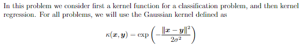

### 21 6.1

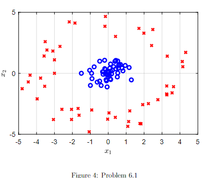

Consider the points in the figure as training points in a dataset where red crosses are class one and blue are class two. Assume you observe a test point of class blue $x_{test}=(-2,0)$.

- Apply kernel function to the closest points of each class in the data set using $\sigma=1$.
- Argue whether the kernel can be useful or not for seperating the two classes.

#### Answer

The two closest points of each class can be read off as :

```python
x_test = np.array([-2,0])
x_red = np.array([-3,0])
x_blue = np.array([-1.5, 0])
sigma = 1
np.set_printoptions(precision=2)

print(gaussian_kernel(x_red, x_test, sigma))
print(gaussian_kernel(x_blue, x_test, sigma))
```

```
[0.61 1.  ]
[0.88 1.  ]
```

Since the kernel $\kappa$ assigns higher value for points of the correct class it can be used.

Much like the exercise 12.1.X and slide 15 week 12 it is definitely linearly seperable in RKHS with the representer theorem.

### 21 6.2

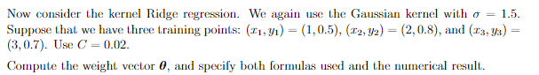

#### Answer

We find on slide 29 from week 12 that:

[figure not shown]

Hence:

$$\hat{\theta}=(\mathcal{K}+CI)^{-1}y$$

where $\mathcal{K}$ is given by (11.11), so:

$$\mathcal{K}= \begin{bmatrix} \kappa(x_1,x_1) & \dots & \kappa(x_1, x_N) \\ \vdots & \ddots & \vdots \\ \kappa(x_N,x_1) & \dots & \kappa(x_N,x_N) \end{bmatrix}$$

```python
sigma = 1.5
C = 0.02
x =  np.array([1, 2, 3]) # x-coordinate values
y = np.array([0.5, 0.8, 0.7]) # y-coordinate values
K = np.zeros((len(x),len(x))) # placeholder

np.set_printoptions(precision=3)
for i in range(K.shape[0]):
    for j in range(K.shape[1]):
        K[i,j] = gaussian_kernel(x[i], x[j], sigma)
KCI = K + C * np.eye(K.shape[0])
theta = np.linalg.inv(KCI) @ y
print(f"K + CI: \n{KCI}")
print(f"theta:\n{theta}")
## First coordinate is slightly diff from solution? Typo?
```

```
K + CI:
[[1.02  0.801 0.411]
 [0.801 1.02  0.801]
 [0.411 0.801 1.02 ]]
theta:
[-0.325  1.037  0.003]
```

### 21 6.3

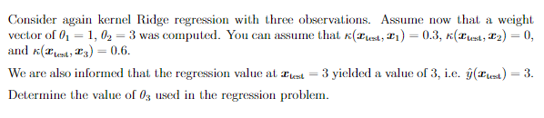

#### Answer

According to eq. (11.27) the prediction of the kernel ride regression can be found as (although $y=f$ in slides):

$$\hat{y}(x)=\sum^N_{n=1}\theta_n\kappa(\cdot,x_n)=\theta_1\kappa(x,x_1)+\theta_2\kappa(x,x_2)+\theta_3\kappa(x,x_3) \\ \Leftrightarrow \\ \theta_3 = \frac{\hat{f(x)}-\theta_1\kappa(x,x_1)+\theta_2\kappa(x,x_2)}{\kappa(x,x_3)} $$

# Exam 2022

## 22 Problem 1

### 22 1.1

Consider linear regression using squared error. You have the following observations:

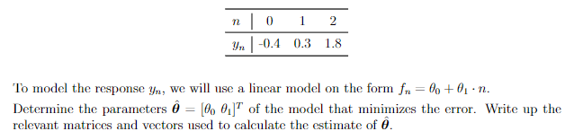

#### Answer

The parameters of linear regression with squared error loss can be readily found as:

$$\hat{\theta} = (X^TX)^{-1}X^Ty$$

where we have $X=\begin{bmatrix}1 & 0 \\ 1 & 1 \\ 1 & 2\end{bmatrix}$, where the columns correspond to the bias $b$ of ones and the observations or predictors $n$. The vector $y_n=[-0.4~~0.3~~1.8]^T$ is readily seen from the data.

```python
import numpy as np
np.set_printoptions(precision=2)
X = np.array([[1,1,1],[0,1,2]]).T
y = np.array([-0.4, 0.3, 1.8])
theta = np.linalg.inv(X.T @ X) @ X.T @ y
print(f"theta = {theta}")
```

```
theta = [-0.53  1.1 ]
```

### 22 1.2

Assume now the parameters are determined with Ridge Regression:

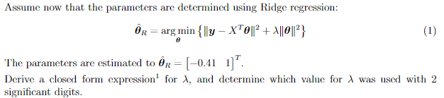

Derive a closed from expression for $\lambda$ and determine its value. Hint: $\lambda \cdot a = b \Rightarrow \lambda=\frac{a^Tb}{a^Ta}$

#### Answer

We start off by finding the solution for $\theta_R$ in the ML book (6.29) or slide 34 week 6:

$$\begin{align*} \theta_R&=(X^TX+\lambda I)^{-1}X^Ty \\ &\Leftrightarrow (X^TX+\lambda I)\theta_R=X^Ty = X^TX\theta_R+\lambda\theta_R=X^Ty \\ &\Leftrightarrow \lambda\theta_R=X^Ty-X^TX\theta_R \Leftrightarrow \lambda=\frac{\theta_R^T(X^Ty-X^TX\theta_R)}{\theta_R^T\theta_R} \end{align*}$$

Inserting and computing gives:

```python
theta_R = np.array([-0.41, 1])
l = (theta_R.T @ (X.T@y - X.T@X@theta_R)) / (theta_R.T@theta_R)
print(f"lambda = {np.round(l, 2)}")
```

```
lambda = 0.14
```

### 22 1.3

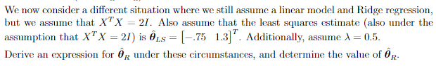

#### Answer

This is almost equivalent to the exercise we did in week 6 for $\theta_{LS}$, albeit $X^TX=2I$, so by direct substitution we can derive that, then use the formula which relates the LS estimate to the RR estimate given on slide 35-ish:

$$\theta_R=\frac{1}{1+\lambda}\theta_{LS}$$ For the LS estimate: $$\begin{align*} \theta_{LS} &= (X^TX)^{-1}X^Ty = (2I)^{-1}X^Ty = \frac{1}{2}X^Ty &\Leftrightarrow X^Ty=2\cdot\theta_{LS} \end{align*}$$ For the Ridge Regression: $$\begin{align*} \theta_{R} &= (X^TX+\lambda I)^{-1}X^Ty = (2I+\lambda I)^{-1}X^Ty \\ &= (I(2+\lambda))^{-1}X^Ty = \frac{1}{2+\lambda}X^Ty = \frac{1}{2+\lambda}2\cdot\theta_{LS}\\ &= \frac{2}{2+\lambda}\theta_{LS} \end{align*}$$

Inserting:

```python
theta_LS = np.array([-0.75, 1.3])
l = 0.5
theta_R = (2 /  (2 + l)) * theta_LS
print(f"theta_R = {theta_R}")
```

```
theta_R = [-0.6   1.04]
```

### 22 1.4

Apply $l_1$ regularization and disregarding the assumption $X^TX=2I$ and instead use IST, we run one iteration of the algorithm. Assume $\theta^{(i-1)}=\theta_{LS}$ from 1.3 and $X^Te^{(i-1)}=[0.25~~-0.35]^T$

Determine lowest value of $\mu$ that results in exactly **one** component of $\theta^{(i)}$ being zero.

#### Answer

$$\theta^{(i)}=S_{\lambda\mu}\bigg(\begin{bmatrix}-0.75 \\1.3 \end{bmatrix}+\mu\begin{bmatrix}0.25 \\ -0.35 \end{bmatrix}\bigg) \\ = \text{sign}\bigg(\begin{bmatrix}-0.75 \\1.3 \end{bmatrix}+\mu\begin{bmatrix}0.25 \\ -0.35 \end{bmatrix}\bigg)\text{max}\bigg(|\begin{bmatrix}-0.75 \\1.3 \end{bmatrix}+\mu\begin{bmatrix}0.25 \\ -0.35 \end{bmatrix}|-\lambda\mu,0\bigg)$$

If simply one component has to be zero we can isolate the difference in the max function and set it to zero, so we can rearrange it as $|\theta|-\lambda\mu=0\Leftrightarrow|\theta|=\lambda\mu$

$$ |-0.75+\mu 0.25|=\lambda\mu =0.5\mu \Leftrightarrow \mu=1~~~~(\text{MAPLE or SYMBOLAB}) \\ |1.3-0.35\mu|=0.5\mu \Leftrightarrow \mu = \frac{26}{17} $$

Hence the lowest value of $\mu$ for one component to be zero is $\mu=1$

### 22 1.5

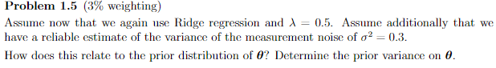

#### Answer

Chapter 12.2.2 in the book eq. (12.12) relates regularized LS (ridge) regression to the MAP estimator as:

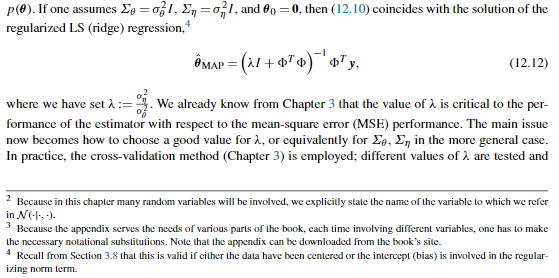

where $\phi=X$ will coincide in the ridge solution. The prior distribution of $\theta$ is assumed Gaussian in eq. (12.8) preceding the above:

$$p(\theta)=\mathcal{N}(\theta|\theta_0=0,\Sigma_\theta=\sigma_\theta^2 I)$$

In other words, there is a direct relation between $\lambda$, measurement noise $\sigma^2_\eta$ and prior variance $\sigma_\theta^2$:

$$ \lambda = \frac{\sigma_\eta^2}{\sigma_\theta^2} \Leftrightarrow \sigma_\theta^2=\frac{\sigma_\eta^2}{\lambda} = \frac{0.3}{0.5} = 0.6 $$